**S2 Statistika Terapan FMIPA Unpad**Dashboard Penjaminan Mutu Pembelajaran

Evaluasi Pembelajaran Mahasiswa

# Dashboard Evaluasi Dosen Semester Genap

Ringkasan kuantitatif dan kualitatif evaluasi pembelajaran dosen berdasarkan rekapitulasi kuesioner mahasiswa Program Studi Statistika Terapan.

Tahun akademik sumber: 2025/2026Semester Genap7 mata kuliah8 dosen

Baca Kata Pengantar Kaprodi ↓

Kata Pengantar Ketua Program Studi

## Terima kasih atas dedikasi dalam proses pembelajaran

Dengan penuh rasa syukur dan penghargaan, saya menyampaikan **terima kasih yang sebesar-besarnya kepada seluruh dosen** yang telah memberikan waktu, tenaga, pemikiran, kesabaran, dan perhatian terbaik dalam pelaksanaan **Proses Belajar Mengajar (PBM) Semester Genap Tahun Akademik 2025/2026**.

Di tengah berbagai kesibukan akademik, penelitian, pengabdian, bimbingan, dan tanggung jawab lainnya, Bapak dan Ibu tetap hadir untuk mendampingi mahasiswa dalam proses belajar. Setiap pertemuan di kelas, setiap diskusi, setiap tugas yang diperiksa, setiap pertanyaan yang dijawab, serta setiap umpan balik yang diberikan merupakan bagian penting dari perjalanan akademik mahasiswa kita.

Bagi mahasiswa, seorang dosen tidak hanya menyampaikan materi. Cara kita menjelaskan, mendengarkan, memberi ruang untuk bertanya, memberikan tantangan, dan mendampingi ketika mereka mengalami kesulitan akan ikut membentuk **cara berpikir, kepercayaan diri, kedewasaan akademik, serta keberanian mereka untuk terus belajar**. Karena itu, kontribusi Bapak dan Ibu jauh melampaui angka yang tercantum dalam laporan evaluasi ini.

Hasil evaluasi ini kami hadirkan bukan untuk sekadar memberi nilai kepada dosen, melainkan sebagai cermin bersama dalam menjaga mutu pembelajaran. **Setiap skor yang baik adalah hasil kerja, perhatian, dan konsistensi yang sering kali tidak terlihat.** Sementara itu, setiap saran mahasiswa merupakan kesempatan bagi kita untuk menyempurnakan hal-hal yang masih dapat diperbaiki tanpa mengurangi penghargaan terhadap kerja keras yang telah diberikan.

Saya menyadari sepenuhnya bahwa kualitas Program Studi S2 Statistika Terapan tidak mungkin dibangun oleh satu orang. Mutu program studi tumbuh dari **komitmen kolektif, rasa memiliki, dan kesediaan seluruh dosen untuk terus berjalan bersama**. Atas kontribusi tersebut, saya menyampaikan penghargaan yang setinggi-tingginya.

Terima kasih telah menjadi bagian penting dari perjalanan mahasiswa dan perjalanan Program Studi S2 Statistika Terapan. Semoga seluruh ilmu, waktu, perhatian, dan ketulusan yang telah Bapak dan Ibu berikan menjadi kebaikan yang terus hidup melalui pencapaian mahasiswa kita. Mari kita terus menjaga suasana akademik yang hangat, kritis, terbuka, dan bermutu, serta bersama-sama menjadikan setiap semester lebih baik daripada semester sebelumnya.

Jatinangor, Agustus 2026

**I Gede Nyoman Mindra Jaya**Ketua Program Studi S2 Statistika Terapan  
FMIPA Universitas Padjadjaran

91%

Skor pembelajaran**4.53 / 5**

Rata-rata tertimbang menurut jumlah responden pada 12 pasangan dosen–mata kuliah.

Partisipasi kuesioner**79.7%**

122 respons dari 153 total peserta-kelas; bukan mahasiswa unik.

Cakupan evaluasi**12**

Pasangan dosen–mata kuliah yang memiliki rekap penilaian pada berkas sumber.

Status umum**Sangat Baik**

Seluruh skor pasangan dosen–mata kuliah berada pada rentang 4,25–4,69.

Gambaran Program

## Kekuatan dan prioritas penguatan

Indikator dihitung sebagai rata-rata tertimbang terhadap jumlah responden pada setiap mata kuliah. Nilai tinggi mendominasi seluruh dimensi pembelajaran.

### Profil 12 indikator evaluasi

Skala 1–5. Bar semakin panjang menunjukkan penilaian mahasiswa yang semakin positif.

01**Kesesuaian materi dengan silabus**

4.54

02**Penyampaian materi menarik dan mudah dipahami**

4.51

03**Contoh kasus mutakhir dan jumlahnya memadai**

4.45

04**Kesempatan bertanya dan partisipasi kelas**

4.45

05**Ketepatan waktu memulai kelas**

4.52

06**Ketepatan waktu mengakhiri kelas**

4.55

07**Kepatuhan terhadap jadwal kuliah**

4.52

08**Kompetensi dosen pada mata kuliah**

4.55

09**Kesesuaian perhitungan SKS per jam**

4.55

10**Kesesuaian alokasi jam dengan beban SKS**

4.55

11**Proporsi teori, praktikum, tugas/kuis**

4.56

12**Kesesuaian waktu dengan kesulitan dan volume materi**

4.56

### Interpretasi utama

Ringkasan deskriptif berbasis angka dan komentar mahasiswa.

**Kompetensi dan pengelolaan beban belajar sangat kuat**

Indikator kompetensi dosen, alokasi jam, proporsi teori–praktikum–tugas, serta kesesuaian waktu dengan volume materi berada sekitar 4,55–4,56.

**Kejelasan materi dinilai konsisten positif**

Komentar berulang menyebut materi jelas, mudah dipahami, menarik, dan proses pembelajaran secara umum sudah baik.

**Ruang penguatan: partisipasi dan contoh kasus**

Dua indikator relatif terendah secara agregat adalah kesempatan bertanya/partisipasi kelas dan ketersediaan contoh kasus mutakhir, walaupun nilainya tetap tinggi (sekitar 4,45).

**Koordinasi tugas dan alur project perlu diperhatikan**

Beberapa usulan meminta tugas tidak diberikan mendadak/berimpit dan agar konsep dasar dijelaskan lebih dulu sebelum presentasi atau project mahasiswa.

Evaluasi per Dosen

## Ringkasan dosen dan tindak lanjut

Foto menggunakan direktori profil dosen yang diberikan. Untuk nama yang tidak tersedia pada direktori tersebut, dashboard menampilkan placeholder agar tidak mengambil foto dari sumber lain.

AA

[figure not shown]

4.60/ 5

Sangat Baik20 respons

### Dr. Anindya Apriliyanti Pravitasari S.Si., M.Si.

Analisis citra · Deep learning · Medical imaging

Penambangan Data dan Kecerdasan BuatanAnalisis Image

Indikator kuat**Kesesuaian materi dengan silabus****4.65**

Relatif terendah**Kesempatan bertanya dan partisipasi kelas****4.31**

**Fokus tindak lanjut**

Pertahankan kekuatan pada kejelasan materi. Penguatan dapat difokuskan pada konsistensi mendorong partisipasi kelas dan stabilitas jadwal, terutama pada Analisis Image.

**Lihat data mata kuliah & komentar**

**Penambangan Data dan Kecerdasan Buatan**4.57

10 responden / 14 mahasiswaResponse rate 71.43%

##### Komentar terpilih

- Materi pembelajaran sangat menarik dan mudah dipahami
- Suka bangett cara ibu ngajar*
- Terimakasih Para dosen semoga kebih baik lagi kedepannya

##### Usulan perbaikan

- Terimakasih Bu atas bimbingannya
- Terimakasih Para dosen semoga kebih baik lagi kedepannya

**Analisis Image**4.64

10 responden / 13 mahasiswaResponse rate 76.92%

##### Komentar terpilih

- Terimakasih Para dosen semoga kebih baik lagi kedepannya

##### Usulan perbaikan

- Terimakasih Para dosen semoga kebih baik lagi kedepannya

BT

[figure not shown]

4.37/ 5

Sangat Baik16 respons

### Dr. Bertho Tantular S.Si., M.Si

Data longitudinal · Model multilevel · Varying coefficient models

Statistika Nonparametrik dan Pemodelan FleksibelBasis Data

Indikator kuat**Contoh kasus mutakhir dan jumlahnya memadai****4.38**

Relatif terendah**Kesesuaian materi dengan silabus****4.29**

**Fokus tindak lanjut**

Kinerja pembelajaran tetap baik. Beberapa komentar mengarah pada harapan terkait penilaian; transparansi rubrik, ekspektasi tugas, dan umpan balik nilai dapat diperkuat.

**Lihat data mata kuliah & komentar**

**Statistika Nonparametrik dan Pemodelan Fleksibel**4.41

12 responden / 14 mahasiswaResponse rate 85.71%

##### Komentar terpilih

- Semoga tambah lebih baik kedepannya
- Terimakasih Pak

##### Usulan perbaikan

- mohon berikan nilai yang lebih bagus pak, karna kita mahasiswa sudah mengerjakan tugas semaksimal mungkin
- Semoga tambah lebih baik kedepannya

**Basis Data**4.25

4 responden / 6 mahasiswaResponse rate 66.67%

##### Komentar terpilih

- terimakasih Pak atas bimbingannya selama proses pembelajaran

##### Usulan perbaikan

- mohon untuk memberikan nilai yg lebih layak lagi pak

DY

[figure not shown]

4.56/ 5

Sangat Baik12 respons

### Dr. Defi Yusti Faidah S.Si., M.Si.

Peramalan · Cuaca dan iklim ekstrem · Clustering

Statistika Nonparametrik dan Pemodelan Fleksibel

Indikator kuat**Kesesuaian materi dengan silabus****4.58**

Relatif terendah**Contoh kasus mutakhir dan jumlahnya memadai****4.31**

**Fokus tindak lanjut**

Pertahankan konsistensi kelas. Contoh kasus mutakhir dapat diperbanyak; terdapat pula preferensi mahasiswa agar sebagian pembelajaran dapat berlangsung secara tatap muka.

**Lihat data mata kuliah & komentar**

**Statistika Nonparametrik dan Pemodelan Fleksibel**4.56

12 responden / 14 mahasiswaResponse rate 85.71%

##### Komentar terpilih

- Semoga tambah lebih baik kedepannya
- Terimakasih Bu atas materi yg sudah di ajarkan

##### Usulan perbaikan

- sayang sekali tidak bisa diajarkan secara offline ya Bu
- Semoga tambah lebih baik kedepannya

SW

[figure not shown]

4.69/ 5

Sangat Baik10 respons

### Dr. Sri Winarni S.Si., M.Si.

Statistical machine learning · Klasifikasi citra · Copula

Analisis Image

Indikator kuat**Kesesuaian materi dengan silabus****4.70**

Relatif terendah**Penyampaian materi menarik dan mudah dipahami****4.60**

**Fokus tindak lanjut**

Hasil sangat kuat pada hampir seluruh indikator. Pertahankan konsistensi pembelajaran dan terus kembangkan variasi penyampaian materi agar capaian tetap terjaga.

**Lihat data mata kuliah & komentar**

**Analisis Image**4.69

10 responden / 13 mahasiswaResponse rate 76.92%

##### Komentar terpilih

- Terimakasih Ibu sudah baik

##### Usulan perbaikan

- Terimakasih Ibu semoga kebih baik lagi kedepannya

IG

[figure not shown]

4.50/ 5

Sangat Baik10 respons

### Irlandia Ginanjar S.Si.

Analisis multivariat · Machine learning · Data kategorik

Pembelajaran Mesin

Indikator kuat**Kesesuaian materi dengan silabus****4.50**

Relatif terendah**Kesesuaian materi dengan silabus****4.50**

**Fokus tindak lanjut**

Seluruh indikator tercatat stabil pada 4,50. Pertahankan konsistensi penyampaian, relevansi materi, dan pengelolaan pembelajaran.

**Lihat data mata kuliah & komentar**

**Pembelajaran Mesin**4.50

10 responden / 14 mahasiswaResponse rate 71.43%

##### Komentar terpilih

- materi sangan jelas dan bisa dipahami
- Semoga tambah lebih baik kedepannya

##### Usulan perbaikan

- Semoga tambah lebih baik kedepannya
- terimakasih atas ilmu yg di ajarkan Pak

AS

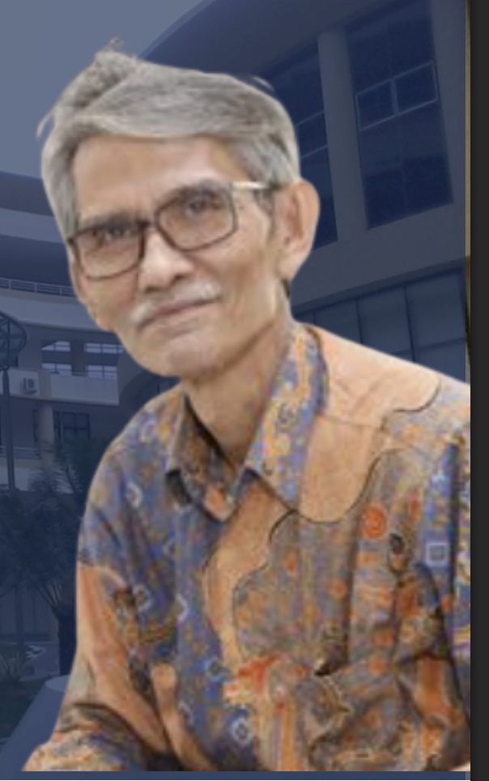

4.57/ 5

Sangat Baik10 respons

### Prof. Dr. Atje Setiawan Abdullah MS., M.Kom.

Dosen pengampu Penambangan Data dan Kecerdasan Buatan

Penambangan Data dan Kecerdasan Buatan

Indikator kuat**Kesesuaian materi dengan silabus****4.60**

Relatif terendah**Contoh kasus mutakhir dan jumlahnya memadai****4.27**

**Fokus tindak lanjut**

Pertahankan konsistensi penyampaian dan pengelolaan kelas. Tambahkan variasi contoh kasus mutakhir karena indikator ini menjadi nilai relatif terendah.

**Lihat data mata kuliah & komentar**

**Penambangan Data dan Kecerdasan Buatan**4.57

10 responden / 14 mahasiswaResponse rate 71.43%

##### Komentar terpilih

- Teirmakasih prof atas bimbingannya
- Terimakasih Para dosen semoga kebih baik lagi kedepannya

##### Usulan perbaikan

- Terimakasih Para dosen semoga kebih baik lagi kedepannya
- Terimakasih Prof

BN

[figure not shown]

4.39/ 5

Sangat Baik12 respons

### Prof. Dr. Budi Nurani Ruchjana MS.

Dosen pengampu Analisis Spasial

Analisis Spasial

Indikator kuat**Proporsi teori, praktikum, tugas/kuis****4.50**

Relatif terendah**Penyampaian materi menarik dan mudah dipahami****4.17**

**Fokus tindak lanjut**

Perkuat porsi penjelasan konsep dasar oleh dosen sebelum presentasi mahasiswa, serta seimbangkan waktu antara penjelasan materi dan project agar alur belajar lebih terstruktur.

**Lihat data mata kuliah & komentar**

**Analisis Spasial**4.39

12 responden / 14 mahasiswaResponse rate 85.71%

##### Komentar terpilih

- penjelasan dan materi yang disampaikan sangat jelas dan mudah dipahami
- Penyampaian materi kurang
- Secara umum penyampaian materi sudah cukup baik dan mudah dipahami. Dosen juga memberikan penjelasan yang jelas serta memberikan kesempatan kepada mahasiswa untuk bertanya. Semoga ke depannya proses pembelajaran dapat semakin interaktif sehingga mahasiswa lebih mudah memahami materi yang disampaikan.
- terimakasih Prof

##### Usulan perbaikan

- materi perkuliahan mohon dijelaskan terlebih dahulu oleh prof, sehingga mahasiswa mudah memahami dan memiliki referensi untuk mengerjakan tugas yg diberikan
- Mungkin untuk sistem pembelajarannya, akan lebih baik jika pada beberapa pertemuan awal dosen menjelaskan materi terlebih dahulu. Setelah mahasiswa sudah memiliki gambaran dan memahami dasar materinya, baru dilanjutkan dengan presentasi.
- Pembagian waktu penyampaian materi dan project bisa disesuaikan lagi
- terimakasih Prof

IG

[figure not shown]

4.53/ 5

Sangat Baik32 respons

### Prof. I Gede Nyoman Mindra Jaya M.Si., Ph.D.

Bayesian statistics · Spatial & spatiotemporal statistics · Disease mapping

Analisis SpasialEpidemiologiPembelajaran Mesin

Indikator kuat**Kesesuaian materi dengan silabus****4.56**

Relatif terendah**Kesempatan bertanya dan partisipasi kelas****4.44**

**Fokus tindak lanjut**

Kinerja sangat baik dan konsisten. Perbaikan utama adalah penjadwalan tugas agar tidak mendadak atau berimpit, serta menjaga ruang partisipasi dan ketepatan waktu pada Epidemiologi.

**Lihat data mata kuliah & komentar**

**Analisis Spasial**4.58

12 responden / 14 mahasiswaResponse rate 85.71%

##### Komentar terpilih

- materi yg diajarkan sangat jelas dan mudah dipahamii
- Secara umum penyampaian materi sudah cukup baik dan mudah dipahami. Dosen juga memberikan penjelasan yang jelas serta memberikan kesempatan kepada mahasiswa untuk bertanya. Semoga ke depannya proses pembelajaran dapat semakin interaktif sehingga mahasiswa lebih mudah memahami materi yang disampaikan.
- terimakasih Prof

##### Usulan perbaikan

- mohon untuk tugas yang diberikan jangan semuanya dadakan pak
- terimakasih Prof

**Epidemiologi**4.44

10 responden / 9 mahasiswaResponse rate 100.00%

##### Komentar terpilih

- materi jelas dan mudah dipahami
- Semoga tambah lebih baik kedepannya

##### Usulan perbaikan

- Semoga tambah lebih baik kedepannya
- untuk tugas mohon tidak diberikan secara mendadak dan bersamaan dengan matkul yang lainnya, terimakasih Pak**

**Pembelajaran Mesin**4.57

10 responden / 14 mahasiswaResponse rate 71.43%

##### Komentar terpilih

- materi yg disampaikan sangat jelas dan bisa dipahami
- Semoga tambah lebih baik kedepannya

##### Usulan perbaikan

- Semoga tambah lebih baik kedepannya
- terimakasih Pak

Data Mata Kuliah

## Rekap pasangan dosen–mata kuliah

| Mata Kuliah | Dosen | Skor | Responden | Response Rate | Indikator Relatif Terendah |
| --- | --- | --- | --- | --- | --- |
| **Analisis Image**140720-UND202522016 | Dr. Anindya Apriliyanti Pravitasari S.Si., M.Si. | 4.64 | 10 / 13 | 76.92% | Kesempatan bertanya dan partisipasi kelas **(4.36)** |
| **Analisis Image**140720-UND202522016 | Dr. Sri Winarni S.Si., M.Si. | 4.69 | 10 / 13 | 76.92% | Penyampaian materi menarik dan mudah dipahami **(4.60)** |
| **Analisis Spasial**140720-UND202522004 | Prof. Dr. Budi Nurani Ruchjana MS. | 4.39 | 12 / 14 | 85.71% | Penyampaian materi menarik dan mudah dipahami **(4.17)** |
| **Analisis Spasial**140720-UND202522004 | Prof. I Gede Nyoman Mindra Jaya M.Si., Ph.D. | 4.58 | 12 / 14 | 85.71% | Kesesuaian materi dengan silabus **(4.58)** |
| **Basis Data**140720-UND202522018 | Dr. Bertho Tantular S.Si., M.Si | 4.25 | 4 / 6 | 66.67% | Kesesuaian materi dengan silabus **(4.25)** |
| **Epidemiologi**140720-UND202522014 | Prof. I Gede Nyoman Mindra Jaya M.Si., Ph.D. | 4.44 | 10 / 9 | 100.00% | Kesempatan bertanya dan partisipasi kelas **(4.11)** |
| **Pembelajaran Mesin**140720-UND202522015 | Irlandia Ginanjar S.Si. | 4.50 | 10 / 14 | 71.43% | Kesesuaian materi dengan silabus **(4.50)** |
| **Pembelajaran Mesin**140720-UND202522015 | Prof. I Gede Nyoman Mindra Jaya M.Si., Ph.D. | 4.57 | 10 / 14 | 71.43% | Contoh kasus mutakhir dan jumlahnya memadai **(4.27)** |
| **Penambangan Data dan Kecerdasan Buatan**140720-UND202522002 | Dr. Anindya Apriliyanti Pravitasari S.Si., M.Si. | 4.57 | 10 / 14 | 71.43% | Kesempatan bertanya dan partisipasi kelas **(4.27)** |
| **Penambangan Data dan Kecerdasan Buatan**140720-UND202522002 | Prof. Dr. Atje Setiawan Abdullah MS., M.Kom. | 4.57 | 10 / 14 | 71.43% | Contoh kasus mutakhir dan jumlahnya memadai **(4.27)** |
| **Statistika Nonparametrik dan Pemodelan Fleksibel**140720-UND202522001 | Dr. Bertho Tantular S.Si., M.Si | 4.41 | 12 / 14 | 85.71% | Kesesuaian materi dengan silabus **(4.31)** |
| **Statistika Nonparametrik dan Pemodelan Fleksibel**140720-UND202522001 | Dr. Defi Yusti Faidah S.Si., M.Si. | 4.56 | 12 / 14 | 85.71% | Contoh kasus mutakhir dan jumlahnya memadai **(4.31)** |

Rencana Tindak Lanjut

## Rekomendasi penjaminan mutu

Rekomendasi disusun agar hasil evaluasi tidak berhenti sebagai skor, tetapi menjadi dasar perbaikan pembelajaran pada semester berikutnya.

1

### Standardisasi desain tugas

Gunakan kalender tugas lintas mata kuliah, rubrik sejak awal, dan tenggat yang tidak menumpuk. Ini menjawab masukan terkait tugas mendadak dan ekspektasi penilaian.

2

### Perkuat pembelajaran interaktif

Pastikan setiap pertemuan memiliki slot diskusi, pertanyaan terarah, dan umpan balik singkat sehingga indikator partisipasi kelas dapat ditingkatkan tanpa menambah beban berlebihan.

3

### Fondasi konsep sebelum project

Untuk mata kuliah berbasis presentasi atau project, berikan kerangka konsep dan contoh kasus terlebih dahulu, lalu lanjutkan ke aktivitas mahasiswa secara bertahap.

**Catatan interpretasi.** Pada dashboard ini, skor **≥ 4,25 dikategorikan sebagai “Sangat Baik”** untuk memudahkan interpretasi hasil evaluasi. Klasifikasi ini digunakan sebagai batas operasional penyajian dashboard. Rata-rata program ditimbang menggunakan jumlah responden. Komentar kualitatif digunakan sebagai konteks untuk perbaikan pembelajaran dan tidak diperlakukan sebagai analisis sentimen otomatis.